# Project

2025-02-12

Jasper Dong and Tosca Wong

I. Introduction

San Francisco is a highly concentrated city with a population of 808,988 people. This city, constructed on a 46.9 square mile area of land, is notorious for its constantly congested highways and traffic. Therefore, instead of driving, people often use public transportation to commute from one place to another. The San Francisco Municipal Railway (MUNI), composed of light rail, cable cars, buses, and streetcars, is a widely popular mode of public transportation in San Francisco.

The overarching goal of our project is to analyze the relationship between the presence of San Francisco Municipal Railway (MUNI) and the location of businesses throughout San Francisco. The goal of this report is to explore where relationships between economic growth/decline and MUNI stops exist, and which neighborhoods this relationship is the most prominent in. According to the 2022 MUNI Rider Survey, one third of MUNI riders use MUNI to travel to and from various businesses. Increased traffic in certain neighborhoods due to increases in business, could result in the need for more MUNI stops in neighborhoods to relieve traffic congestion. According to the Transit Economic Benefits Study, the highest amount of MUNI ridership occurs in neighborhoods of high congestion. The purpose of this report is to observe which neighborhoods have the most MUNI stops and analyze them for any correlation with the number of businesses established in the neighborhood.

Research Question: Is there a relationship between the number of businesses and MUNI stops in San Francisco for each neighborhood?

```r
## Load packages
library(terra)
library(tidyverse)
```

```r
library(ggplot2)
```

```r
## Unzipping files
unzip("Data.zip")
dir.create("muni", showWarnings = FALSE)
dir.create("nhood", showWarnings = FALSE)
unzip("MUNI.zip", exdir="muni")
unzip("nhood.zip", exdir="nhood")
```

2. Data Summary

Our data sources come from DataSF, which is San Francisco’s official open data portal, collected internally from various government offices. Data sources included are MUNI Stops for mapping MUNI transit points, Registered Business Locations for mapping existing businesses, and Analysis Neighborhoods for obtaining neighborhood boundaries. The San Francisco Population and Demographic Census Data is also included later in this report, for further analysis and discussion.

```r
##Transforming longitude and latitude data so that it can be read as a vector
##for the businesses data.

bis <- read.csv("Registered_Business_Locations_-_San_Francisco_20250212.csv", sep = ";")
regex1 <- "POINT \\("
bis$Business.Location <- gsub(regex1, "", bis$Business.Location)

regex2 <- "\\)"
bis$Business.Location <- gsub(regex2, "", bis$Business.Location)

bis_lonlat <- bis %>%
  separate(Business.Location, c("lon", "lat"), sep = " ") %>%
  mutate(lon = as.numeric(lon),
         lat = as.numeric(lat))
bisv <- vect(bis_lonlat, geom = c("lon", "lat"))
```

```r
## Vectorize Muni data
muni<- vect("muni/geo_export_7a61b6cd-add6-411a-bdc0-6a4be0880140.dbf")
muni
```

```
##  class       : SpatVector
##  geometry    : points
##  dimensions  : 3285, 22  (geometries, attributes)
##  extent      : -122.5108, -122.367, 37.7059, 37.82985  (xmin, xmax, ymin, ymax)
##  source      : geo_export_7a61b6cd-add6-411a-bdc0-6a4be0880140.dbf
##  coord. ref. : lon/lat WGS 84 (EPSG:4326)
##  names       :  objectid        stopname trapezesto rucusstopa stopid latitude
##  type        :     <num>           <chr>      <chr>      <chr>  <num>    <num>
##  values      : 7.287e+04 17th St&Noe St~   17ST.NO0   17ST.NOE   3318    37.76
##                7.362e+04 Judah St&12th ~   JUDA12A0   JUDA12AV   5195    37.76
##                7.368e+04 Mansell St&Som~   MANSSOM0   MANSSOME   5351    37.72
##  longitude accessibil    atstreet   onstreet (and 12 more)
##      <num>      <num>       <chr>      <chr>
##     -122.4        NaN      NOE ST    17TH ST
##     -122.5          1    12TH AVE   JUDAH ST
##     -122.4        NaN SOMERSET ST MANSELL ST
```

```r
## Vectorize San Fransico Neighborhood Data
newv <- vect("nhood/geo_export_188f3512-6e48-45bc-ad4c-ef55315e7720.dbf")
newv
```

```
##  class       : SpatVector
##  geometry    : polygons
##  dimensions  : 41, 1  (geometries, attributes)
##  extent      : -122.5149, -122.357, 37.70813, 37.8333  (xmin, xmax, ymin, ymax)
##  source      : geo_export_188f3512-6e48-45bc-ad4c-ef55315e7720.dbf
##  coord. ref. : lon/lat WGS 84 (EPSG:4326)
##  names       :              nhood
##  type        :              <chr>
##  values      :   Western Addition
##                West of Twin Peaks
##                 Visitacion Valley
```

```r
## Counting the amount of businesses in each neighborhood (**the line below also takes at least 10 mins to run)
count <- terra::extract(newv, bisv)

noNAcount <- count %>%
  filter(!is.na(nhood))

neighborhood <- noNAcount%>%
  group_by(nhood) %>%
  summarize(point_count = n())

join <- merge(newv, neighborhood, by="nhood")
point_count <- join[["point_count"]]

## Counting the amount of Muni stops in each neighborhood
muni_count <- terra::extract(newv, muni)
munistops <- muni_count%>%
  group_by(nhood)%>%
  summarize(munipoint_count = n())

muni_join <- merge(newv, munistops, by = "nhood")

busmuni_join <- merge(muni_join, join, by = "nhood")
```

```r
# Converting count data to proportion data
join$prop <- join$point_count/sum(join$point_count)

muni_join$prop <- muni_join$munipoint_count/sum(muni_join$munipoint_count)

join
```

```
##  class       : SpatVector
##  geometry    : polygons
##  dimensions  : 41, 3  (geometries, attributes)
##  extent      : -122.5149, -122.357, 37.70813, 37.8333  (xmin, xmax, ymin, ymax)
##  coord. ref. : lon/lat WGS 84 (EPSG:4326)
##  names       :              nhood point_count     prop
##  type        :              <chr>       <int>    <num>
##  values      :   Western Addition        5121  0.01878
##                West of Twin Peaks        7739  0.02838
##                 Visitacion Valley        1755 0.006436
```

```r
muni_join
```

```
##  class       : SpatVector
##  geometry    : polygons
##  dimensions  : 41, 3  (geometries, attributes)
##  extent      : -122.5149, -122.357, 37.70813, 37.8333  (xmin, xmax, ymin, ymax)
##  coord. ref. : lon/lat WGS 84 (EPSG:4326)
##  names       :              nhood munipoint_count    prop
##  type        :              <chr>           <int>   <num>
##  values      :   Western Addition              55 0.01684
##                West of Twin Peaks             220 0.06736
##                 Visitacion Valley              70 0.02143
```

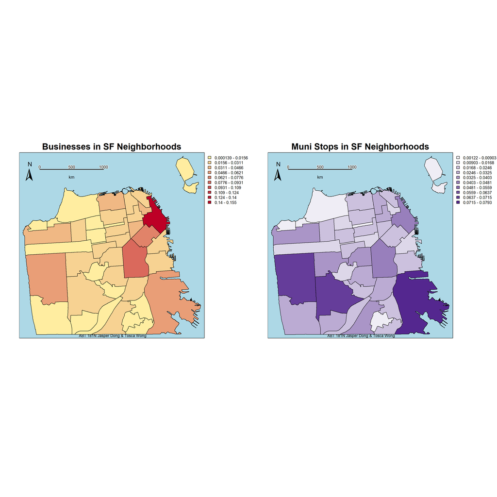

```r
## Plot Muni and Business data

par(mfrow = c(1,2))

##Picking color palette for Businesses map
YlOrRd <- RColorBrewer::brewer.pal(n=9, name ="YlOrRd")
colors = colorRampPalette(c("#FFEDA0", "#BD0026"))

##Picking color palette for Businesses map
Purple <- RColorBrewer::brewer.pal(n=9, name ="Purples")
colors1 = colorRampPalette(c("#EFEDF5", "#54278F"))

## Businesses in Each Neighborhood Map
plot(join, "prop", breaks= 10, col = colors(10), background = "lightblue",
     main= "Businesses in SF Neighborhoods", axes=FALSE, cex.main = 1.7)
text(x=-122.435, y=37.7072, "ABT 181N Jasper Dong & Tosca Wong", col = "black", cex=0.75)
lines(newv, col="black")
north(xy= "topleft", type=2, cex= 1.2)
sbar(5, xy=c(-122.5,37.824), type="line", divs=2, labels=c(0,500,1000),
   scaleby=100, lonlat=NULL, cex=0.8, below = "km")

## Muni Stops in Each Neighborhood Map
plot(muni_join, "prop", breaks = 10, col = colors1(10), background = "lightblue",
     main= "Muni Stops in SF Neighborhoods", axes=FALSE, cex.main = 1.7)
text(x=-122.435, y=37.7072, "ABT 181N Jasper Dong & Tosca Wong", col = "black", cex=0.75)
lines(newv, col="black")
north(xy= "topleft", type=2, cex= 1.2)
sbar(5, xy=c(-122.5,37.824), type="line", divs=2, labels=c(0,500,1000),
   scaleby=100, lonlat=NULL, cex=0.8, below = "km")
```

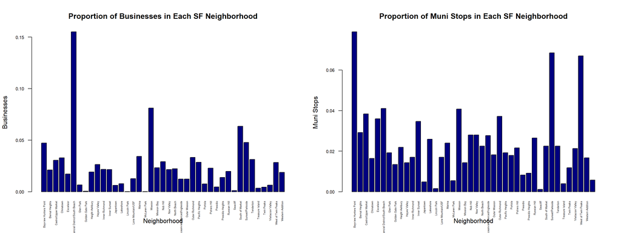

```r
par(mfrow = c(1,2))

##Bar Plot indicating the proportion of businesses to the total number of businesses in each SF neighborhood
barplot(height = neighborhood$point_count/sum(neighborhood$point_count), names.arg = neighborhood$nhood,
  main = "Proportion of Businesses in Each SF Neighborhood",
  xlab = "Neighborhood", ylab = "Businesses",
  col = "navy", cex.names =0.4, las = 2, cex.axis = 0.7)

##Bar Plot indicating the proportion of Muni stops to the total number of Muni stops in each neighborhood
barplot(height = munistops$munipoint_count/sum(munistops$munipoint_count), names.arg = munistops$nhood,
  main = "Proportion of Muni Stops in Each SF Neighborhood",
  xlab = "Neighborhood", ylab = "Muni Stops",
  col = "navy", cex.names =0.4, las = 2, cex.axis = 0.7)
```

3. Analysis

To prepare our data for modeling, potential outliers that can heavily influence our results are identified by creating boxplots for each of our variables of interest, as shown in Fig. 3. The boxplots identify three outliers for each of our variables. Outliers that belong to the MUNI Stop variable are the neighborhoods West of Twin Peaks, Sunset/Parkside, and Bayview Hunters Point, which are all residential neighborhoods. Outliers belonging to the Business variable are the neighborhoods South of Market (SoMa), Mission, and the Financial District, which are all primarily commercial areas.

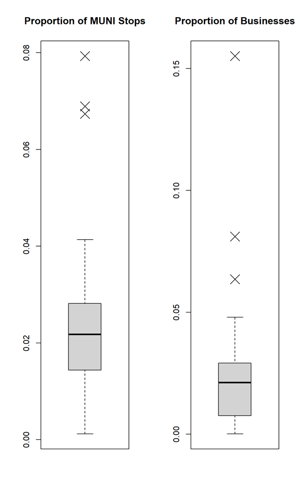

```r
## Checking for outliers
par(mfrow=c(1, 2))
boxplot(muni_join$prop, main="Proportion of MUNI Stops",
        outcex = 2.5, outpch = 4)
boxplot(join$prop, main="Proportion of Businesses",
        outcex = 2.5, outpch = 4)
```

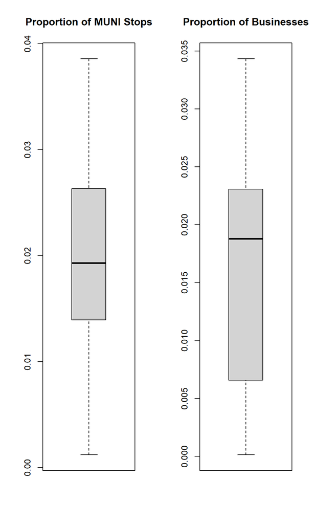

```r
busmuni_join$muniprop <- busmuni_join$munipoint_count/sum(busmuni_join$munipoint_count)
busmuni_join$pointprop <- busmuni_join$point_count/sum(busmuni_join$point_count)
# Obtain values of outliers
muniout <- boxplot.stats(busmuni_join$muniprop)$out
busout <- boxplot.stats(busmuni_join$pointprop)$out
# Obtaining indices
muniout_idx <- which(busmuni_join$muniprop %in% muniout)
busout_idx <- which(busmuni_join$pointprop %in% busout)
outidx <- c(muniout_idx, busout_idx)
# Removing outliers
df <- values(busmuni_join)
dfclean <- df[-outidx, ]
# Re-plotting boxplots
par(mfrow=c(1, 2))
boxplot(dfclean$muniprop, main="Proportion of MUNI Stops")
boxplot(dfclean$pointprop, main="Proportion of Businesses")
```

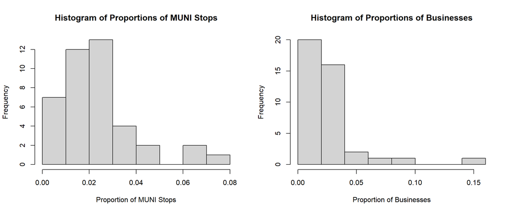

```r
# Plotting histograms
par(mfrow=c(1,2))

hist(busmuni_join$muniprop, main = "Histogram of Proportions of MUNI Stops",
     xlab = "Proportion of MUNI Stops")
hist(busmuni_join$pointprop, main = "Histogram of Proportions of Businesses",
     xlab = "Proportion of Businesses")
```

A simple linear regression model is fitted between the two variables, with MUNI Stops being used as the independent variable and Businesses being used as the dependent variable. A visualization of the fitted regression model is shown, along with numerical summaries.

```r
# Fitting linear regression model
lin <- lm(pointprop ~ muniprop, data=dfclean)
linsum <- summary(lin)
linsum
```

```
##
## Call:
## lm(formula = pointprop ~ muniprop, data = dfclean)
##
## Residuals:
##       Min        1Q    Median        3Q       Max
## -0.013284 -0.006134 -0.001709  0.004670  0.018394
##
## Coefficients:
##             Estimate Std. Error t value Pr(>|t|)
## (Intercept) 0.003155   0.003152   1.001    0.324
## muniprop    0.686342   0.144862   4.738 3.99e-05 ***
## ---
## Signif. codes:  0 '***' 0.001 '**' 0.01 '*' 0.05 '.' 0.1 ' ' 1
##
## Residual standard error: 0.008423 on 33 degrees of freedom
## Multiple R-squared:  0.4048, Adjusted R-squared:  0.3868
## F-statistic: 22.45 on 1 and 33 DF,  p-value: 3.985e-05
```

```r
# Obtaining correlation between MUNI Stops and Businesses
correlation = cor(dfclean$muniprop, dfclean$pointprop)
correlation
```

```
## [1] 0.6362732
```

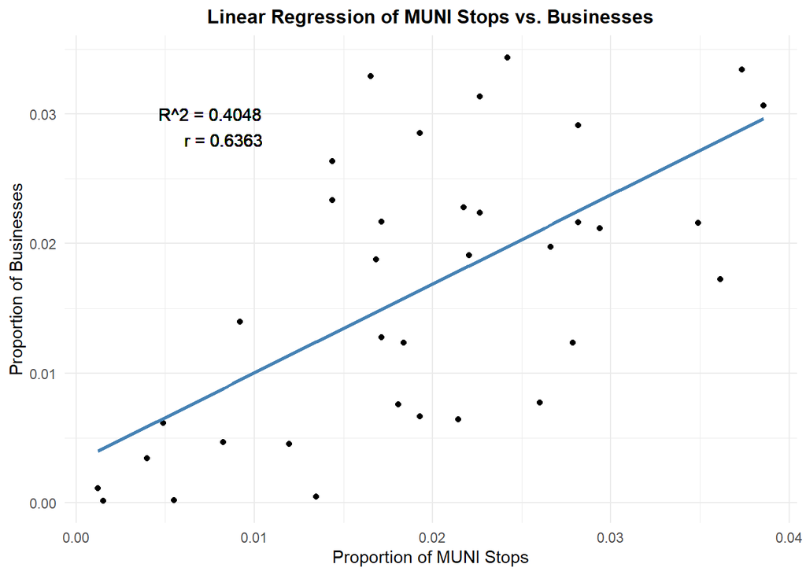

```r
# Plotting linear relationship between MUNI stops and Businesses
ggplot(data = dfclean, aes(x = muniprop, y = pointprop)) +
  geom_point() +
  geom_smooth(method='lm', se=FALSE, color = "steelblue") +
  theme_minimal() +
  labs(x = 'Proportion of MUNI Stops', y = 'Proportion of Businesses',
       title = 'Linear Regression of MUNI Stops vs. Businesses') +
  theme(plot.title = element_text(hjust=0.5, size=12, face='bold')) +
  geom_text(x = 0.0075, y = 0.03,
            label = paste0("R^2 = ", round(linsum$r.squared, 4))) +
  geom_text(x = 0.0083, y = 0.028,
            label = paste0("r = ", round(correlation, 4)))
```

The fitted regression model gives a correlation coefficient of r = 0.6363 and a coefficient of determination of R2 = 0.4048. These results imply that there is an existing positive relationship between MUNI Stops and Businesses, yet this relationship is fairly weak and may not be linear. This can mean that while a positive relationship exists between the two variables, MUNI Stops may not be a good predictor for Businesses. Another interpretation could be that the relationship between MUNI Stops and Businesses may be spurious - in other words, they may be associated but not by a casual relationship. There may be other variables along with MUNI Stops that may better help explain the variation in Businesses, which are further explored in the following section.

4. Discussion

To further explore the possibility that additional variables - along with MUNI Stops - may help better explain the variability present in Businesses, this report will include demographic data from DataSF’s San Francisco Population and Demographic Census Data into our analysis. This analysis will include race variables of each neighborhood along with the MUNI Stop data. As this analysis is not within the original scope of this report, detailed analysis will be avoided.

The data pre-processing steps for these race variables will remain similar to our initial pre-processing, with the exception that proportional measurements will be respective to neighborhood populations instead of to the entire San Francisco population. Six race variables are used in the analysis, which include data on Native American, Asian, Black, Hispanic, Pacific Islander, and White populations. A multiple linear regression model is fitted between the race variables and the MUNI Stops variable against the Businesses variable. The fitted model found a resulting adjusted R2 = 0.4483, which is a marginal increase compared to the earlier fitted simple linear regression model. This implies that although adding the race variables does have an additional positive effect on explaining the variation present in the Businesses variable, the modeled relationship is still a fairly weak one.

```r
# Reading in demographic data
demo <- read_csv("Demo.csv")
# Filtering by race and time categories
demo <- demo[which(demo$demographic_category == "race"),]
demo <- demo[which(demo$end_year == 2023),]
# Selecting variables of interest
democlean <- demo |>
  select(all_of(c("geography_name",
                  "demographic_category_label",
                  "estimate")))
colnames(democlean)[1] <- "nhood"
# Obtaining unique race groups
racelab <- sort(unique(democlean$demographic_category_label))
racelab
```

```
## [1] "American Indian and Alaska Native alone, Not Hispanic or Latino:"
## [2] "Asian alone, Not Hispanic or Latino:"
## [3] "Black or African American alone, Not Hispanic or Latino:"
## [4] "Hispanic or Latino:"
## [5] "Native Hawaiian and Other Pacific Islander alone, Not Hispanic or Latino:"
## [6] "Some other race alone, Not Hispanic or Latino:"
## [7] "Two or more races:, Not Hispanic or Latino:"
## [8] "White alone, Not Hispanic or Latino:"
```

```r
# Splitting data frame into separate race groups
splitrace <- split(democlean, democlean$demographic_category_label)
# Dropping unnecessary categories
splitrace <- splitrace[-c(6, 7)]
# Obtaining estimate counts
## Selecting count data and coercing into data frame
racecount <- lapply(splitrace, function(x){x |> select("estimate")})
names(racecount) <- c("native", "asian", "black", "hisp", "pi", "white")
race <- as.data.frame(mapply(cbind, racecount))
## Calculating total population counts for each nhood
race$total <- rowSums(race)
race$nhood <- splitrace[[1]]$nhood
## Turning counts into proportions by each nhood
race[,1:6] = round(race[,1:6]/race$total, 4)
colnames(race)[1:6] <- names(racecount)
head(race)
```

```
##   native  asian  black   hisp     pi  white total
## 1 0.0002 0.4059 0.2446 0.2562 0.0127 0.0804 37994
## 2 0.0022 0.1513 0.0334 0.3616 0.0000 0.4515 22595
## 3 0.0044 0.1434 0.0270 0.1067 0.0035 0.7150 20415
## 4 0.0005 0.8401 0.0145 0.0436 0.0000 0.1012 12239
## 5 0.0033 0.5022 0.0158 0.3155 0.0063 0.1570 36795
## 6 0.0004 0.4761 0.0209 0.0972 0.0051 0.4002 23473
##                            nhood
## 1          Bayview Hunters Point
## 2                 Bernal Heights
## 3            Castro/Upper Market
## 4                      Chinatown
## 5                      Excelsior
## 6 Financial District/South Beach
```

```r
# Merging into SpatVector
demo.join <- merge(busmuni_join, race, by = "nhood")
demo.join
```

```
##  class       : SpatVector
##  geometry    : polygons
##  dimensions  : 41, 12  (geometries, attributes)
##  extent      : -122.5149, -122.357, 37.70813, 37.8333  (xmin, xmax, ymin, ymax)
##  coord. ref. : lon/lat WGS 84 (EPSG:4326)
##  names       :             nhood munipoint_count point_count muniprop pointprop
##  type        :             <chr>           <int>       <int>    <num>     <num>
##  values      :  Western Addition              55        5121  0.01684   0.01878
##                  West of Twin P~             220        7739  0.06736   0.02838
##                Visitacion Valley              70        1755  0.02143  0.006436
##  native  asian  black   hisp     pi  white     total
##   <num>  <num>  <num>  <num>  <num>  <num>     <num>
##  0.0006  0.302  0.155 0.1222 0.0093 0.4109 1.985e+04
##   0.002 0.3919 0.0233 0.1106 0.0001 0.4721 3.406e+04
##  0.0018 0.5914 0.0672 0.2225 0.0182  0.099 1.645e+04
```

```r
# Turning into data frame
dfrace = values(demo.join)
# Removing previous outliers
outidxcomb <- c()
for(i in 4:11){
  out <- boxplot.stats(dfrace[,i])$out
  outidx <- which(dfrace[,i] %in% out)
  outidxcomb <- c(outidxcomb, outidx)
}

dfrace.clean <- dfrace[-unique(outidxcomb), ]
head(dfrace.clean)
```

```
##               nhood munipoint_count point_count    muniprop   pointprop native
## 1  Western Addition              55        5121 0.016840171 0.018779016 0.0006
## 4        Twin Peaks              39        1237 0.011941212 0.004536154 0.0004
## 7  Presidio Heights              30        3810 0.009185548 0.013971500 0.0000
## 8          Presidio              27        1274 0.008266993 0.004671835 0.0028
## 9      Potrero Hill              71        6221 0.021739130 0.022812782 0.0001
## 10          Portola              59        2075 0.018064911 0.007609150 0.0000
##     asian  black   hisp     pi  white total
## 1  0.3020 0.1550 0.1222 0.0093 0.4109 19849
## 4  0.2286 0.0502 0.1688 0.0000 0.5519  7445
## 7  0.2409 0.0067 0.1080 0.0000 0.6444  9423
## 8  0.0647 0.0110 0.2674 0.0000 0.6540  3182
## 9  0.2747 0.0276 0.1414 0.0000 0.5563 13860
## 10 0.7093 0.0292 0.1416 0.0000 0.1199 13634
```

```r
multilin <- lm(pointprop ~ muniprop + native + asian + black +
                 hisp + pi + white, data = dfrace.clean)

multilin.sum <- summary(multilin)
multilin.sum
```

```
##
## Call:
## lm(formula = pointprop ~ muniprop + native + asian + black +
##     hisp + pi + white, data = dfrace.clean)
##
## Residuals:
##        Min         1Q     Median         3Q        Max
## -0.0145824 -0.0039544 -0.0008504  0.0048864  0.0133183
##
## Coefficients:
##             Estimate Std. Error t value Pr(>|t|)
## (Intercept)  -8.9836    25.0076  -0.359 0.723185
## muniprop      0.6548     0.1631   4.014 0.000681 ***
## native        8.9024    24.8953   0.358 0.724393
## asian         8.9829    25.0071   0.359 0.723198
## black         8.9591    25.0164   0.358 0.724000
## hisp          8.9619    25.0107   0.358 0.723857
## pi           10.0975    24.9446   0.405 0.689925
## white         8.9951    25.0080   0.360 0.722850
## ---
## Signif. codes:  0 '***' 0.001 '**' 0.01 '*' 0.05 '.' 0.1 ' ' 1
##
## Residual standard error: 0.007264 on 20 degrees of freedom
## Multiple R-squared:  0.5913, Adjusted R-squared:  0.4483
## F-statistic: 4.134 on 7 and 20 DF,  p-value: 0.005804
```

[output not shown]

V. Conclusion

The goal of this report was to find if there was a relationship between the proportion of MUNI stops and the proportion of businesses on a neighborhood-wise basis in San Francisco. Although the methods used did find a positive relationship between the two variables, the relationship is fairly weak and may not be linear.

Many limitations were faced in this report, including a potential violation of assumptions for the models used. The distributions of the original data saw a skewed distribution, which meant that the normal distribution assumption for the simple linear regression model could have been violated. Although the later multiple linear regression model is outside of the scope of the original report, this violation could have further extended to the fitted model. A non-parametric regression model, such as a regression tree or a Random Forest model, may have been a better choice for modeling our data. Exploring these methods would require much further analysis beyond the scope of this report.

Additionally, the choice for data may not have been ideal. The MUNI Stops variable and Businesses variable could potentially not have been good proxies for transit rates or local economic health. Better choice of variables, such as changes in ridership rates or changes in income, may be more accurate in analyzing the relationship that motivated this report. Analyzing the relationship on the basis of variables that change over time would require an analysis that uses completely different methods, such as a time series analysis. Further analysis can be done through the use of zoning data, as businesses tend to be concentrated in areas of commercial or mixed use zoning, while transit stops may be concentrated in areas zoned for residential use.

Overall, although the analysis conducted in this report was relatively simple, the results are still meaningful enough to motivate future analysis. The relationship that was found between the two variables was not completely non-existent, and although the relationship may be spurious, it could mean that there are other factors that can help associate the correlation between the two variables. As we saw with our further analysis of adding in race variables, this could require the consideration of many different factors in order to effectively capture the complex relationship between transit stops and local economic health.

References Brophy, Jeanne. “2022 Muni Rider Survey.” SFMTA, 6 Feb. 2023, www.sfmta.com/blog/2022-muni-rider-survey.

SFMTA Citizens Advisory Committee2. “SFMTA.” Transit Economic Benefits Study, 3 Sept. 2015, www.sfmta.com/media/29156/download?inline=.